# Final_Project_Darryl_Nagal

Darryl Nagal

2025-11-09

## Uploading the dataset for the final project

```r
long_term <- read.csv("~/Downloads/long-term-care-facility-staffing.csv")

library("dplyr")
```

## Quick summary of the dataset and its structure

```r
str(long_term)
```

```
## 'data.frame':    5589 obs. of  15 variables:
##  $ YEAR        : int  2015 2014 2013 2012 2011 2015 2014 2013 2012 2011 ...
##  $ FAC_NO      : int  206010734 206010734 206010734 206010734 206010734 206010744 206010744 206010744 206010744 206010744 ...
##  $ FAC_NAME    : chr  "CROWN BAY NURSING AND REHABILITATION CENTER" "CROWN BAY NURSING AND REHABILITATION CENTER" "CROWN BAY NURSING AND REHABILITATION CENTER" "CROWN BAY NURSING AND REHABILITATION CENTER" ...
##  $ BEG_DATE    : chr  "01/01/2015 12:00:00 AM" "01/01/2014 12:00:00 AM" "01/01/2013 12:00:00 AM" "01/01/2012 12:00:00 AM" ...
##  $ END_DATE    : chr  "12/31/2015 12:00:00 AM" "12/31/2014 12:00:00 AM" "12/31/2013 12:00:00 AM" "12/31/2012 12:00:00 AM" ...
##  $ COUNTY_NAME : chr  "Alameda" "Alameda" "Alameda" "Alameda" ...
##  $ TYPE_CNTRL  : chr  "Investor Owned" "Investor Owned" "Investor Owned" "Investor Owned" ...
##  $ PATIENT_DAYS: int  44998 44246 42097 43421 42496 10922 10274 10935 10924 10536 ...
##  $ PRDHR_MGT   : int  1470 2080 1929 2400 2251 2080 2080 2080 2080 2080 ...
##  $ PRDHR_RN    : int  22807 34169 31808 31404 32196 3782 3554 3475 1698 1973 ...
##  $ PRDHR_LVN   : int  17457 16499 16755 15734 10999 6433 3771 4372 5874 6341 ...
##  $ PRDHR_NA    : int  91467 128880 117611 104339 112704 24877 23449 25224 21701 20384 ...
##  $ PRDHR_TSP   : int  2827 4378 2087 3242 3853 0 0 0 0 0 ...
##  $ PRDHR_PSY   : int  0 0 0 0 0 0 0 0 0 0 ...
##  $ PRDHR_OTH   : int  1530 2200 2040 2056 1991 0 0 0 0 0 ...
```

## Dataset dimensions

```r
dim(long_term)
```

```
## [1] 5589   15
```

## Checking if the dataset contains any missing values

```r
sum(is.na(long_term))
```

```
## [1] 0
```

## Checking the normality of the distributions for the nursing staff roles of interest

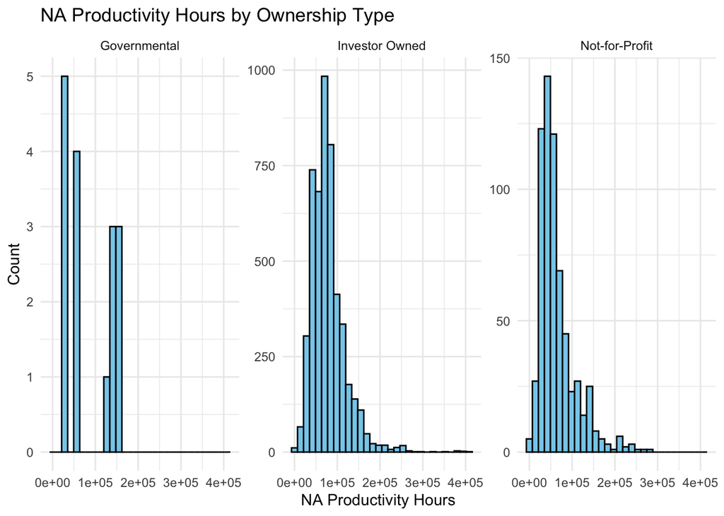

```r
#NA productive hours histogram
library(ggplot2)

ggplot(long_term, aes(x = PRDHR_NA)) +
  geom_histogram(fill = "skyblue", color = "black", bins = 30) +
  facet_wrap(~ TYPE_CNTRL, scales = "free_y") +
  labs(
    title = "NA Productivity Hours by Ownership Type",
    x = "NA Productivity Hours",
    y = "Count"
  ) +
  theme_minimal()
```

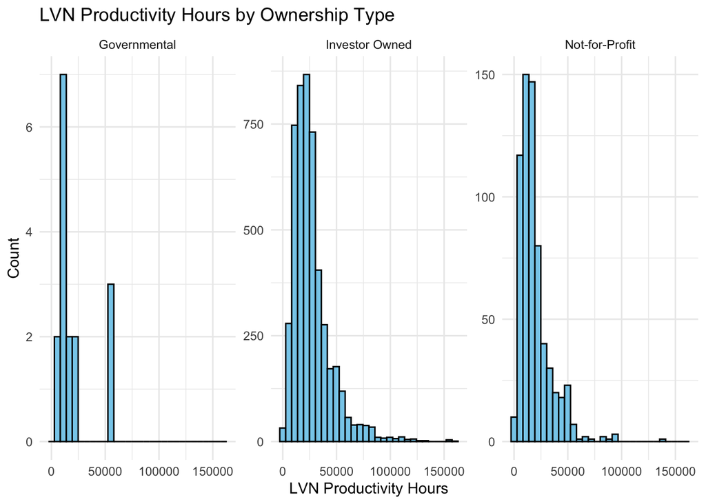

```r
#LVN productive hours histogram
ggplot(long_term, aes(x = PRDHR_LVN)) +
  geom_histogram(fill = "skyblue", color = "black", bins = 30) +
  facet_wrap(~ TYPE_CNTRL, scales = "free_y") +
  labs(
    title = "LVN Productivity Hours by Ownership Type",
    x = "LVN Productivity Hours",
    y = "Count"
  ) +
  theme_minimal()
```

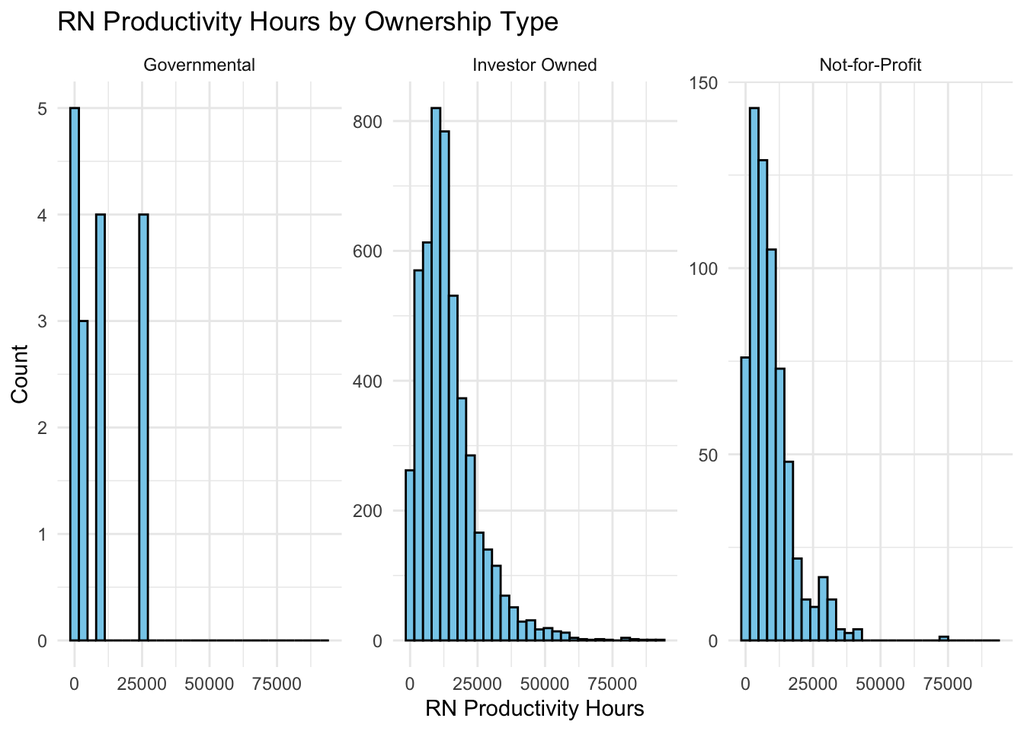

```r
#RN productive hours histogram
ggplot(long_term, aes(x = PRDHR_RN)) +
  geom_histogram(fill = "skyblue", color = "black", bins = 30) +
  facet_wrap(~ TYPE_CNTRL, scales = "free_y") +
  labs(
    title = "RN Productivity Hours by Ownership Type",
    x = "RN Productivity Hours",
    y = "Count"
  ) +
  theme_minimal()
```

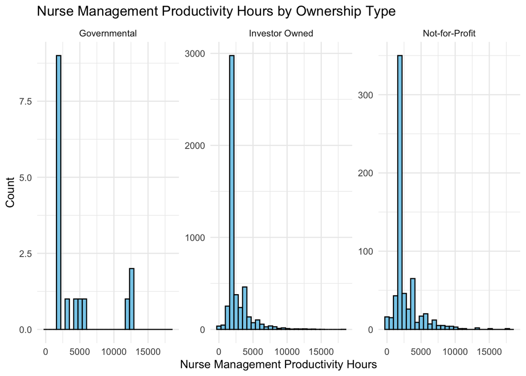

```r
#Nurse Management productive hours histogram
ggplot(long_term, aes(x = PRDHR_MGT)) +
  geom_histogram(fill = "skyblue", color = "black", bins = 30) +
  facet_wrap(~ TYPE_CNTRL, scales = "free_y") +
  labs(
    title = "Nurse Management Productivity Hours by Ownership Type",
    x = "Nurse Management Productivity Hours",
    y = "Count"
  ) +
  theme_minimal()
```

## Also evaluating normality by using QQ plots for each position

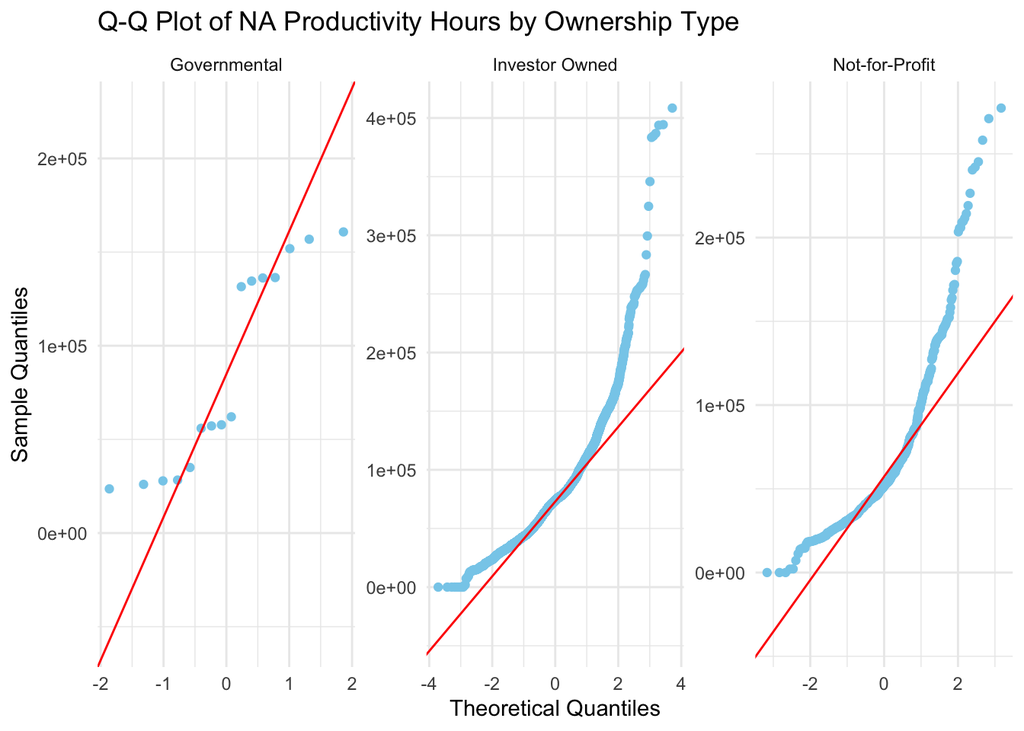

```r
#NA QQ plot
ggplot(long_term, aes(sample = PRDHR_NA)) +
  stat_qq(color = "skyblue") +
  stat_qq_line(color = "red") +
  facet_wrap(~ TYPE_CNTRL, scales = "free") +
  labs(
    title = "Q-Q Plot of NA Productivity Hours by Ownership Type",
    x = "Theoretical Quantiles",
    y = "Sample Quantiles"
  ) +
  theme_minimal()
```

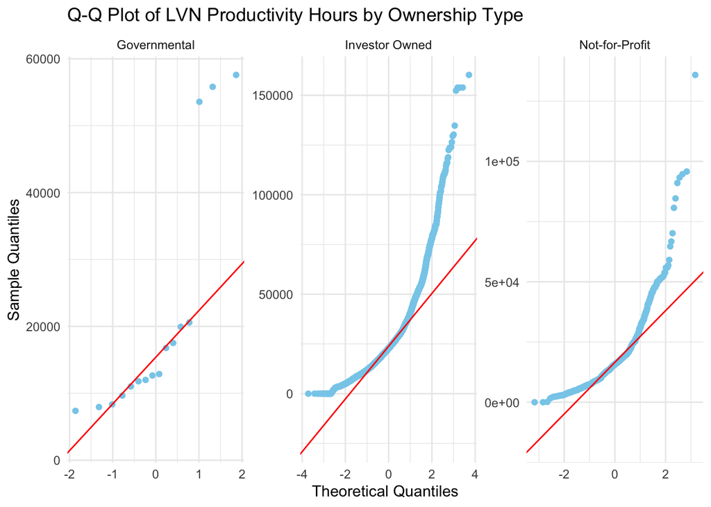

```r
#LVN QQ plot
ggplot(long_term, aes(sample = PRDHR_LVN)) +
  stat_qq(color = "skyblue") +
  stat_qq_line(color = "red") +
  facet_wrap(~ TYPE_CNTRL, scales = "free") +
  labs(
    title = "Q-Q Plot of LVN Productivity Hours by Ownership Type",
    x = "Theoretical Quantiles",
    y = "Sample Quantiles"
  ) +
  theme_minimal()
```

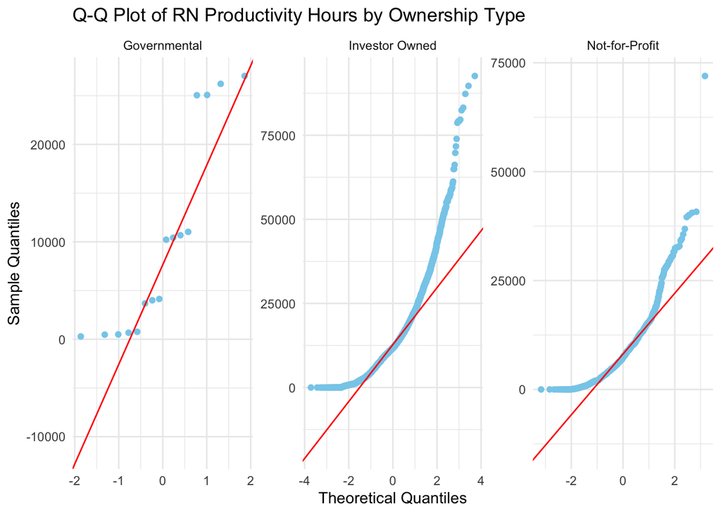

```r
#RN QQ plot
ggplot(long_term, aes(sample = PRDHR_RN)) +
  stat_qq(color = "skyblue") +
  stat_qq_line(color = "red") +
  facet_wrap(~ TYPE_CNTRL, scales = "free") +
  labs(
    title = "Q-Q Plot of RN Productivity Hours by Ownership Type",
    x = "Theoretical Quantiles",
    y = "Sample Quantiles"
  ) +
  theme_minimal()
```

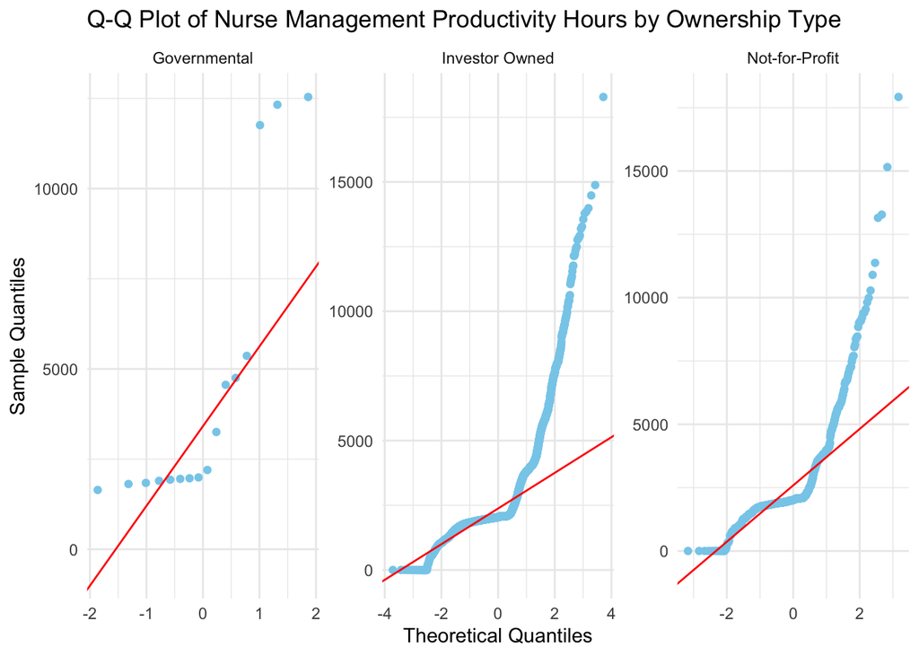

```r
#MGT QQ plot
ggplot(long_term, aes(sample = PRDHR_MGT)) +
  stat_qq(color = "skyblue") +
  stat_qq_line(color = "red") +
  facet_wrap(~ TYPE_CNTRL, scales = "free") +
  labs(
    title = "Q-Q Plot of Nurse Management Productivity Hours by Ownership Type",
    x = "Theoretical Quantiles",
    y = "Sample Quantiles"
  ) +
  theme_minimal()
```

## Given that the distributions are skewed, we will see if any of the productive hours (NA, LVN, RN, and Nurse Management) are correlated using spearman’s rank correlation

```r
cor_matrix <- cor(long_term[, c("PRDHR_NA", "PRDHR_LVN", "PRDHR_RN", "PRDHR_MGT")],
                  use = "pairwise.complete.obs",
                  method = "spearman")

cor_matrix
```

```
##            PRDHR_NA PRDHR_LVN  PRDHR_RN PRDHR_MGT
## PRDHR_NA  1.0000000 0.7884086 0.6315515 0.3071226
## PRDHR_LVN 0.7884086 1.0000000 0.4880205 0.2996350
## PRDHR_RN  0.6315515 0.4880205 1.0000000 0.2296882
## PRDHR_MGT 0.3071226 0.2996350 0.2296882 1.0000000
```

## Performing a KMO now that strong correlations were found

```r
library(psych)
KMO(cor_matrix)
```

```
## Kaiser-Meyer-Olkin factor adequacy
## Call: KMO(r = cor_matrix)
## Overall MSA =  0.68
## MSA for each item =
##  PRDHR_NA PRDHR_LVN  PRDHR_RN PRDHR_MGT
##      0.62      0.66      0.77      0.92
```

Results indicate that there is common variance for PCA to be performed given that the value is greater than 0.60

## Principal Component Analysis for Staffing Structure

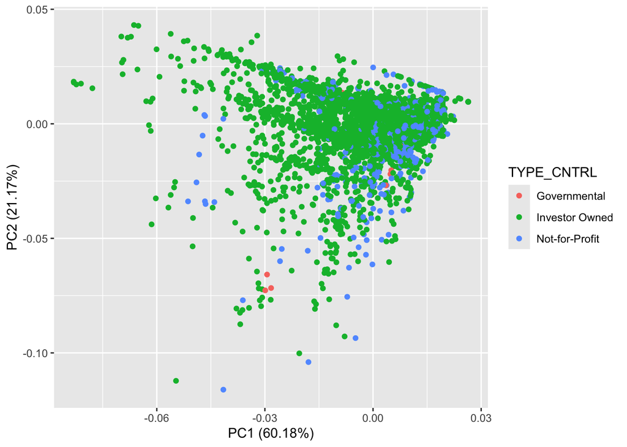

```r
pca_result <- prcomp(long_term[, c("PRDHR_NA", "PRDHR_LVN", "PRDHR_RN", "PRDHR_MGT")],
                     scale. = TRUE)

library(ggfortify)
autoplot(pca_result, data = long_term, color = 'TYPE_CNTRL')
```

```r
summary(pca_result)
```

```
## Importance of components:
##                           PC1    PC2    PC3     PC4
## Standard deviation     1.5515 0.9201 0.7141 0.48600
## Proportion of Variance 0.6018 0.2117 0.1275 0.05905
## Cumulative Proportion  0.6018 0.8135 0.9409 1.00000
```

```r
pca_result$rotation
```

```
##                  PC1        PC2         PC3          PC4
## PRDHR_NA  -0.5783892  0.1939926  0.23047820  0.758097984
## PRDHR_LVN -0.5550413  0.2027824  0.50520238 -0.628950767
## PRDHR_RN  -0.5088420  0.1435667 -0.83113788 -0.172273825
## PRDHR_MGT -0.3138072 -0.9490178  0.02932873 -0.005487246
```

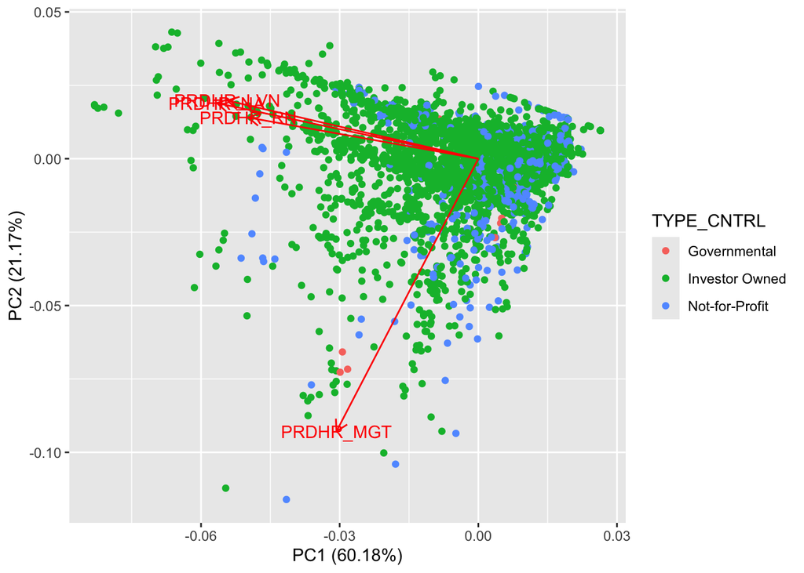

```r
autoplot(pca_result, data = long_term, color = 'TYPE_CNTRL',
         loadings = TRUE, loadings.label = TRUE)
```

## Checking the shape of the distribution for PC1 and PC2

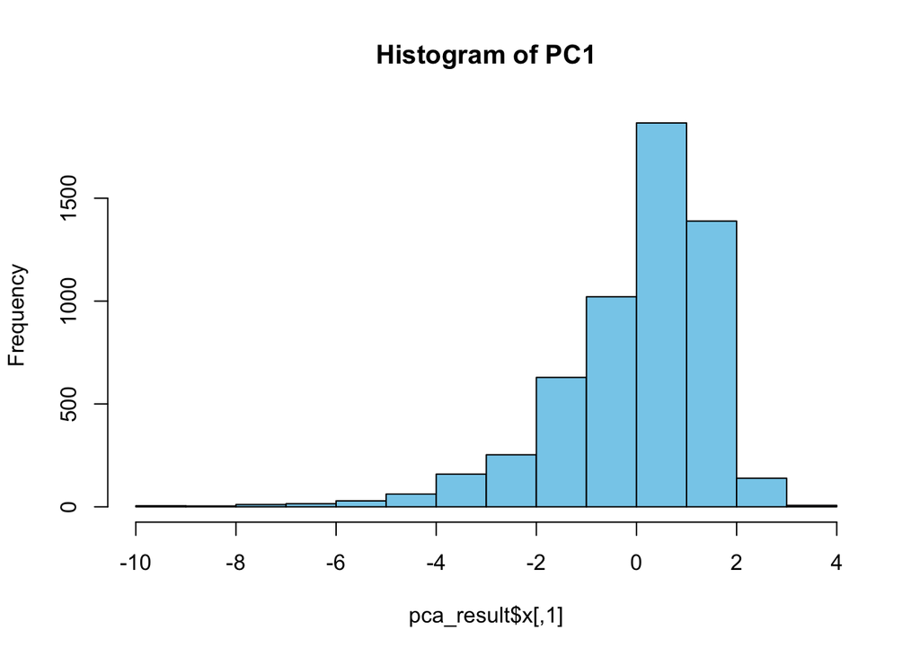

```r
hist(pca_result$x[,1],
     main = "Histogram of PC1",
     xlab = "pca_result$x[,1]",
     col = "skyblue")
```

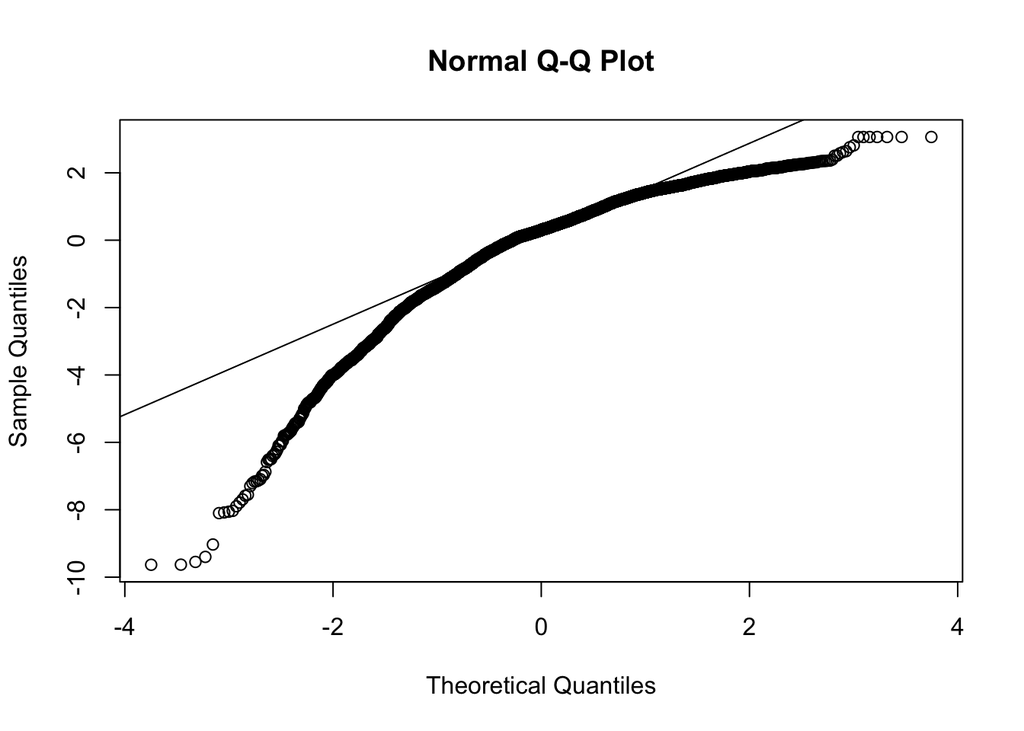

```r
qqnorm(pca_result$x[,1]); qqline(pca_result$x[,1])
```

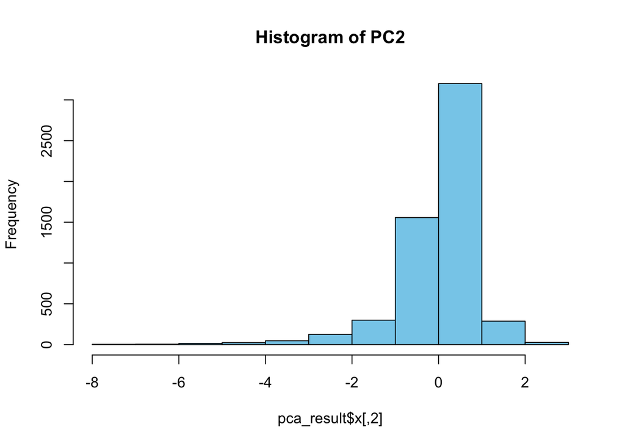

```r
hist(pca_result$x[,2],
     main = "Histogram of PC2",
     xlab = "pca_result$x[,2]",
     col = "skyblue")
```

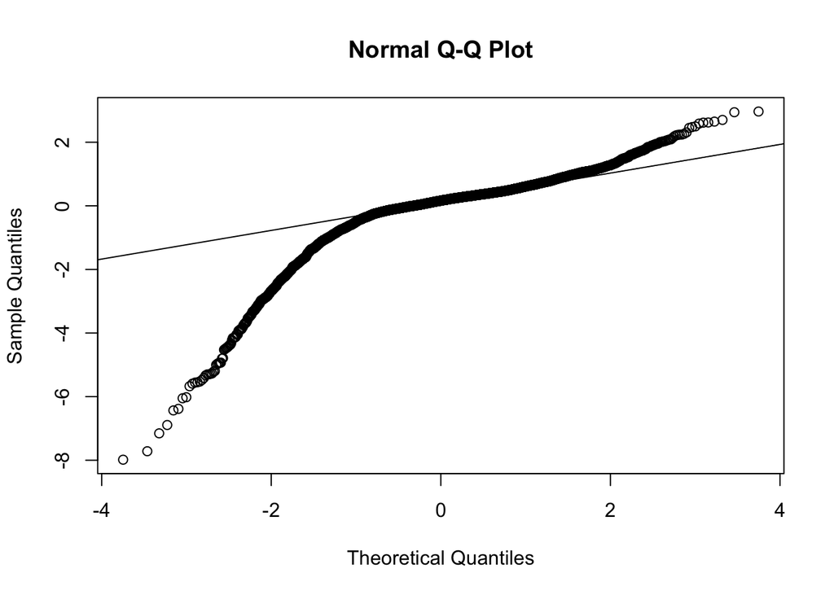

```r
qqnorm(pca_result$x[,2]); qqline(pca_result$x[,2])
```